# World's Gross Domestic Product (GDP) Analysis from 2001-2018

## by Hassanat Awodipe

## Investigation Overview

I am interested in looking at the world's GDP as a whole. I want to understand how the positive correlation between Population and GDP is affected by inflation and how GDP Per Capita varies with Income Class and Regions.

## Dataset Overview

The dataset contained 3,072 observations of economic features from 172 unique countries. These features include exports, imports, gross national savings and expendtiure, total natural resources rents and inflation.

## Distribution of GDP

GDP has a long tail with a lot of smaller values and just a few values on the high side. When plotted on a log scale, the distribution appears to be normal with the highest count of GDPs in 10B range.

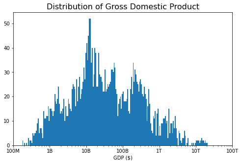

## Growth of GDP and Population from 2001 - 2018

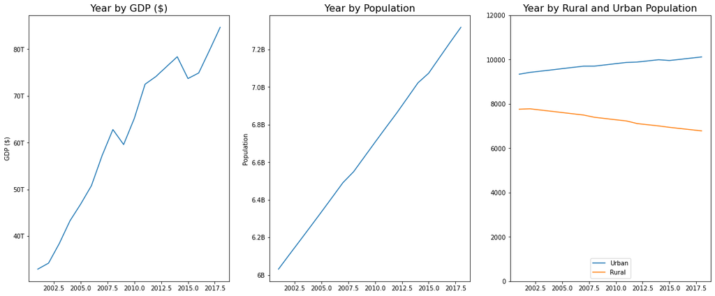

```
By examining based on Rural and Urban Population, we can see that the specific increase in urban population maybe
related to that of GDP. Also interesting to see that the migration from Rural areas to Urban areas continues to grow.
```

## Close Examination of the Fall of GDP in 2015

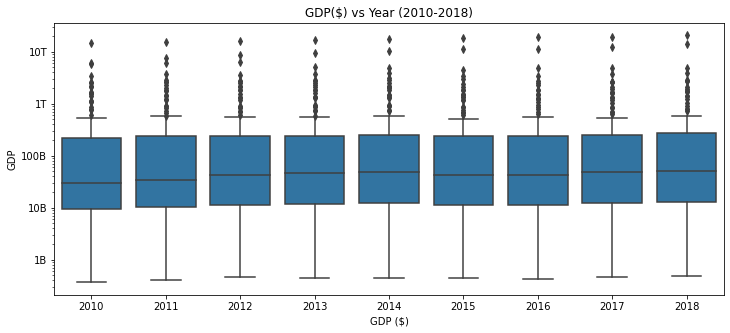

## GDP and Population by Inflation

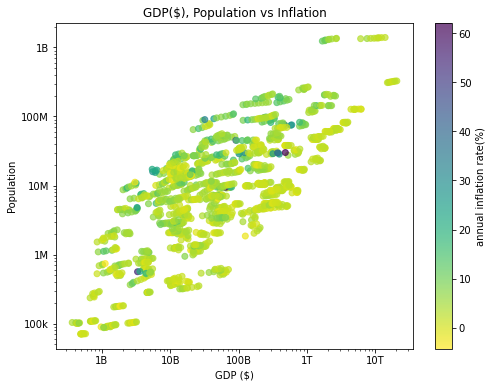

[output not shown]

## GDP and Population Distribution by Regions

Here we see that some of the regions with high GDP values do not have a high number of population. Narrow violin plots indicate that the distribution of that region across that GDP value is very small.

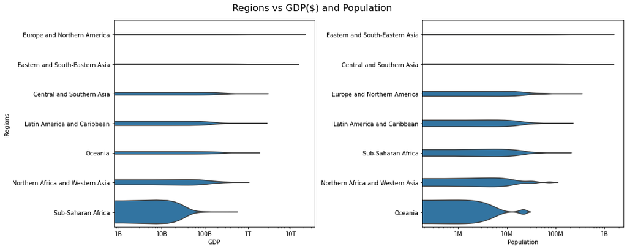

## GDP and Population Distribution by Income Class

The violin plots here are less narroe. We see that as the GDP value for high income increases, the distribution gets smaller. Considering the four classes, the distribution becomes more and Low income has the highest number of points.

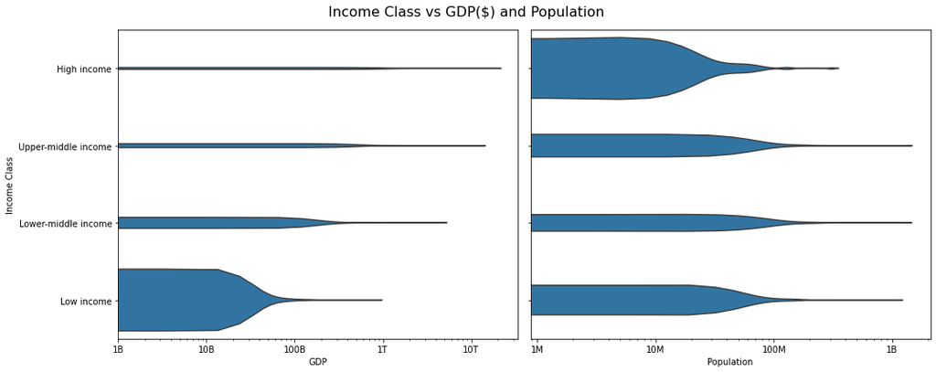

## GDP Per Capita

Oceania is the region with the second highest GDP Per Capita despite having the lowest number of observations in the dataset. Conversly, Eastern and South-Eastern Asia is the region with the the highest population observations but and it has the third highest GDP Per Capita. This shows that high GDP is not entirely dependent on increase in population. The average GDP Per Capita for the income classes have a close range excluding the high income class.

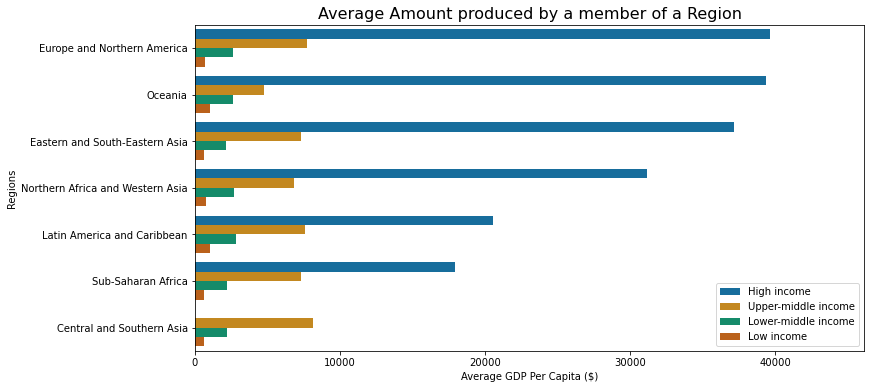

```
Central and Southern Asia has no population of high income but has the second highest number of observations
in the datset.
```